# Introduction to QualCoder

Setting up a project, coding interview transcripts and running reports in a free qualitative analysis program

Author

NC State University Libraries — Data Science Services

Published

November 10, 2026

Open this guide anywhere: go.ncsu.edu/dss-intro-qualcoder

**ImportantHow to use this guide**

This is the page we work from in the session. Every step is written out, so you can follow along, catch up if you fall behind, and come back to it later.

- **Steps are in purple boxes** titled with where you do them: *In your browser*, *In Finder* (Mac), *In File Explorer* (Windows) or *In QualCoder*. Everything outside a box explains what the steps do.
- **Mac and Windows steps are in tabs.** Where the two differ, pick your system’s tab once and every tab on the page switches to match.
- **This guide is for QualCoder version 3.8.2.** There is a version 4.0, but it is very new and some of its menus have changed.

# Welcome

## What you’ll be able to do

- Install QualCoder and set up a project folder that keeps your data and backups safe.
- Create a QualCoder project and import interview transcripts into it.
- Code transcripts, and add memos and annotations as you go.
- Run reports of your coded text and memos to start your analysis.

## Roadmap for today

1. **See where we’re headed.** We start with a look at a finished project, below.
2. **Set up a project folder** on your computer and download today’s transcripts into it (Section 1).
3. **Install QualCoder** (Section 2).
4. **Create a QualCoder project**, set your coder name and turn on backups (Section 3).
5. **Import transcripts** and describe them with attributes (Section 4).
6. **Code**: watch a short demo, then code a transcript yourself for 5 minutes (Section 5).
7. **Run reports** of coded text and memos (Section 6).
8. **Close the project**, then reopen it to find your first backup (Section 7).

More things to try, including how to work on a project with a team, are in Extra activities.

### What we’re not doing today

- **We’re not using QualCoder’s AI features.** QualCoder can connect to AI tools, but sending research data to an AI service has IRB implications. Always check with your advisor and your IRB protocol before turning them on.
- **We’re not covering how to do qualitative research.** Today is about the software: how to set up a project and use QualCoder’s tools.

### Where we’re headed

By the end of the session you’ll have a project that looks like this: three interviews with singers, coded with a few codes (each has its own color), a memo or two, and a report that pulls together everything you coded in the interviews.

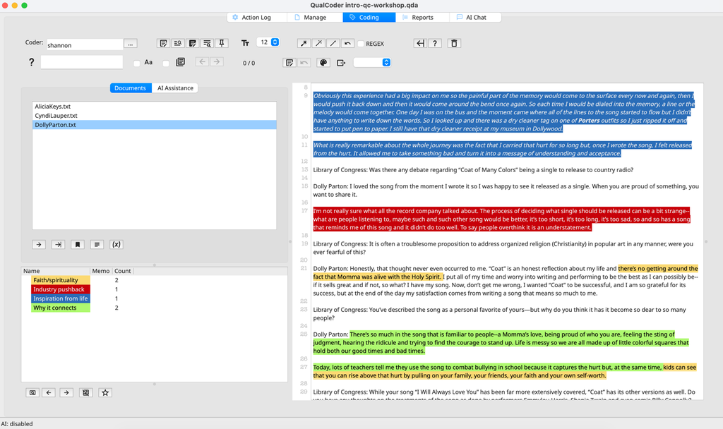

The Coding tab of a finished project: the Dolly Parton interview with passages highlighted in each code’s color.

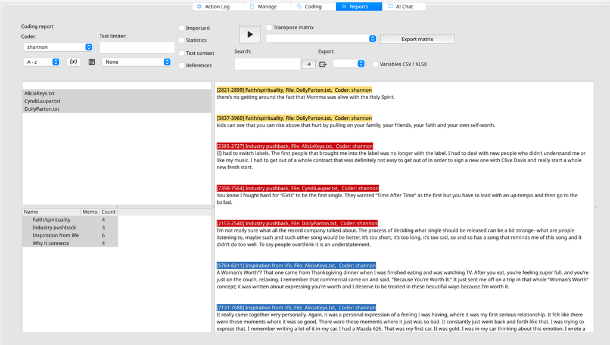

A report of all the codes in all three interviews.

# 1 Set up your project folder

Before you install QualCoder, decide where your project will live and make a folder for it. A QualCoder project is a folder ending in `.qda` that holds a database of your codes, memos and copies of your files. Keeping it in a folder of its own, next to your original data and your backups, makes the project easy to find, copy and hand on.

**WarningGotcha: don’t use cloud storage for the project folder**

Don’t put the project folder in OneDrive, Google Drive, Dropbox, Box or iCloud. QualCoder keeps its database open while you work, and a sync program copying it at the same time can damage it or create conflicting copies.

Watch out for folders that sync without you noticing: on a Mac, **Desktop** and **Documents** may be synced to iCloud; on Windows, they may be synced to OneDrive. Your home folder is usually a safe place. Back up by copying the closed project somewhere else, not by syncing it.

You’ll make a folder called `qualcoder-workshop` with two folders inside it: `data`, for your original interview files, and `backups`, for QualCoder’s automatic backups. Later, QualCoder adds the project itself, `intro-qc-workshop.qda`, next to them (Section 3).

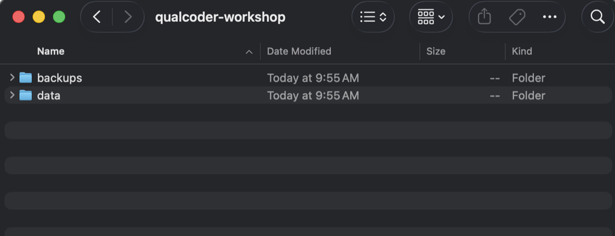

The finished project folder (shown on a Mac).

**Mac**

**NoteIn Finder: make the project folders**

1. Open **Finder** and go to your home folder: **Go > Home** (or **Cmd + Shift + H**).
2. Make a new folder (**File > New Folder**, or **Cmd + Shift + N**) and name it `qualcoder-workshop`.
3. Open `qualcoder-workshop` and make two folders inside it: `data` and `backups`.

**Windows**

**NoteIn File Explorer: make the project folders**

1. Open **File Explorer** and go to your user folder: `C:\Users\<your name>`. (Not **Documents** or **Desktop**, which may sync to OneDrive.)
2. Make a new folder (**New > Folder**, or **Ctrl + Shift + N**) and name it `qualcoder-workshop`.
3. Open `qualcoder-workshop` and make two folders inside it: `data` and `backups`.

## 1.1 Get today’s transcripts

Today we’ll code three interviews with singers, from the Library of Congress. Each was done when one of the singer’s recordings was added to the [National Recording Registry](https://www.loc.gov/programs/national-recording-preservation-board/recording-registry/), and each singer answers similar questions: where the songs came from, how the record got made and why it still connects with people. That overlap makes them good for coding: the same ideas come up in all three, in different words.

| Singer | Recording | Interview | Length |
| --- | --- | --- | --- |
| Dolly Parton | “Coat of Many Colors” (1971) | 2016 | about 850 words |
| Cyndi Lauper | *She’s So Unusual* (1983) | 2019 | about 1,600 words |
| Alicia Keys | *Songs in A Minor* (2001) | 2022 | about 2,350 words |

**Our research question for today:** *How do singers describe where their songs come from, and why those songs connect with people?* A real study would start from a question like this; we use it to decide what to code.

These three come from the Library of Congress’s [index of Recording Registry interviews](https://www.loc.gov/programs/national-recording-preservation-board/recording-registry/index-of-interviews/), which has interviews with more than 100 other musicians, producers and songwriters, as PDFs.

**NoteIn your browser: download the interviews**

1. Click each link to download the interview as a text file:
   - DollyParton.txt
   - CyndiLauper.txt
   - AliciaKeys.txt
2. If a file opens in your browser instead of downloading, go back, then right-click the link (on a Mac, Control-click) and choose **Download Linked File** or **Save link as**.
3. Move the three files from your **Downloads** folder into `qualcoder-workshop/data`.

The Library of Congress shares the interviews as PDFs, and they weren’t made for analysis: every line ends in a line break, even mid-sentence, and the interviewer is labeled “LOC”, “Library of Congress” or “LC”. For today, we’ve made plain-text copies with only the formatting tidied: each paragraph is joined back together, and the speakers are always labeled “Library of Congress:” and the singer’s name. The words are unchanged, including the editors’ notes in [square brackets].

Ideally, transcripts are **clean** like this before you import them: speaker labels consistent, typos fixed, and names and identifying details removed if the participants were promised confidentiality. QualCoder imports plain text (`.txt`), Word (`.docx`) and PDF files.

**TipExtra: who owns an interview?**

The interviews are copyrighted by their authors. The Library of Congress’s license lets it allow noncommercial scholarly and educational reuse, and it gave us permission to share these text copies for this workshop. Each file starts with a note saying so. When you reuse someone else’s interviews in your research, check the license and the terms of use first.

# 2 Install QualCoder

QualCoder is free, open-source software for qualitative data analysis. It runs on your own computer, so your data stays with you. If you installed it before the session, check that it opens and skip ahead to Section 3.

**WarningGotcha: the newest QualCoder is 4.0, but we use 3.8.2**

QualCoder 4.0 came out in October 2026, so QualCoder’s website now offers 4.0, and its menus differ from this guide. Use the download links below to get 3.8.2.

**Mac**

**NoteIn your browser and Finder: install on a Mac**

1. Download QualCoder_3_8_2_macOs_arm64.dmg (547 MB).
2. Open the downloaded file from your **Downloads** folder.
3. In the window that opens, drag **QualCoder** into your **Applications** folder.
4. Open QualCoder from **Applications**. If your Mac won’t open it and shows a warning about the app, go to **System Settings > Privacy & Security**, scroll down and click **Open Anyway**.

**WarningGotcha: 3.8.2 is for Apple silicon Macs only**

The 3.8.2 Mac download runs only on Macs with Apple silicon (M1 or later). To check yours, open the **Apple menu > About This Mac**: it lists a **Chip** (Apple M1, M2, …) or a **Processor** (Intel). There’s no Intel version of 3.8.2; the most recent Intel Mac version is 3.7 (`QualCoder.3.7.Mac.X86.dmg`), and some menus may differ from this guide.

**Windows**

**NoteIn your browser and File Explorer: install on Windows**

1. Download QualCoder_3_8_2_Win_setup.exe (246 MB).
2. Find the setup wizard in your **Downloads** folder and double-click it to start.
3. When asked, choose **Download only for me**. On university computers you can’t install it for all users.
4. Click through the rest of the wizard, then click **Finish**.
5. Let the setup wizard open QualCoder when the installation is complete.

## 2.1 The first time QualCoder opens

**NoteIn QualCoder: the first time it opens**

1. Wait. QualCoder is not very quick to open.
2. When it asks whether you want to set up AI, click **No**. You can always set it up later.

# 3 Create a QualCoder project

## 3.1 Menus and tabs

QualCoder has two ways to get around, and this guide uses both:

- **The top menu**: **Project**, **Manage**, **Coding**, **Reports**, **AI** and **Help**. On a Mac, it’s in the menu bar at the top of the screen, after the **Qualcoder** menu. On Windows, it’s at the top of the QualCoder window.
- **The tabs** inside the QualCoder window: **Action Log**, **Manage**, **Coding**, **Reports** and **AI Chat**. Choosing an item from the top menu often opens one of these tabs.

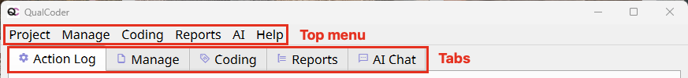

The top menu and the tabs, at the top of the QualCoder window on Windows.

## 3.2 Create the project

**Mac**

[figure not shown]

**NoteIn QualCoder: create a new project**

1. Go to **Project > Create New Project** (or **Cmd + N**).
2. In the save window, go to your `qualcoder-workshop` folder.
3. Name the project `intro-qc-workshop` and click **Save**. QualCoder adds `.qda` to the name.
4. The project opens right away in QualCoder.

**Windows**

[figure not shown]

**NoteIn QualCoder: create a new project**

1. Go to **Project > Create New Project** (or **Ctrl + N**).
2. In the save window, go to your `qualcoder-workshop` folder.
3. Name the project `intro-qc-workshop` and click **Save**. QualCoder adds `.qda` to the name.
4. The project opens right away in QualCoder.

## 3.3 Set your coder name

QualCoder records who coded each passage. Set your name now, so your codes are labeled with it. This is especially important when you check coding between coders or team members, to make sure codes are applied consistently.

The settings are in a different menu on each system.

**Mac**

**NoteIn QualCoder: open the settings**

1. Go to **Qualcoder > Preferences…** (or **Cmd + ,**). On a Mac, the settings are in the **Qualcoder** menu, not the **Project** menu.

[figure not shown]

On a Mac, the settings are under Preferences in the Qualcoder menu.

**Windows**

**NoteIn QualCoder: open the settings**

1. Go to **Project > Settings** (or **Alt + S**).

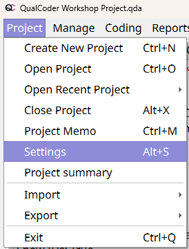

Settings is in the Project menu.

The Settings window and the coder list are the same on both systems.

**NoteIn QualCoder: set your coder name**

1. Next to **Current coder**, click **Change**.
2. Click **New**, type your coder name and click **OK**.
3. Make sure your coder name has a check mark next to it.
4. Click **OK**.

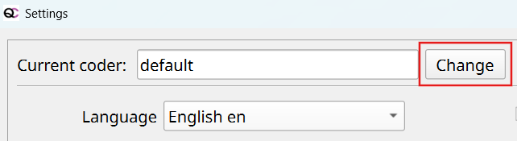

The Change button next to Current coder. A new project’s coder is called default.

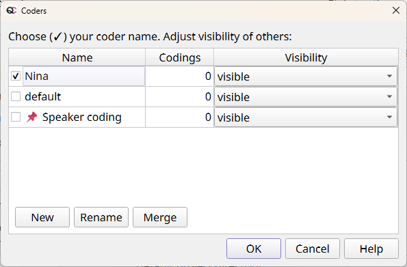

The coder list after adding a new coder name. The check mark shows which name is in use.

## 3.4 Turn on backups to your backups folder

QualCoder can keep backups of your project for you. Point it at the `backups` folder you made.

**Mac**

**NoteIn QualCoder: set the backup folder**

1. Go to **Qualcoder > Preferences…** (or **Cmd + ,**).
2. Click **Default project directory**.
3. Go to `qualcoder-workshop` and click **once** on `backups` to select it (don’t double-click into it).
4. Click **Open**.
5. Click **OK**.

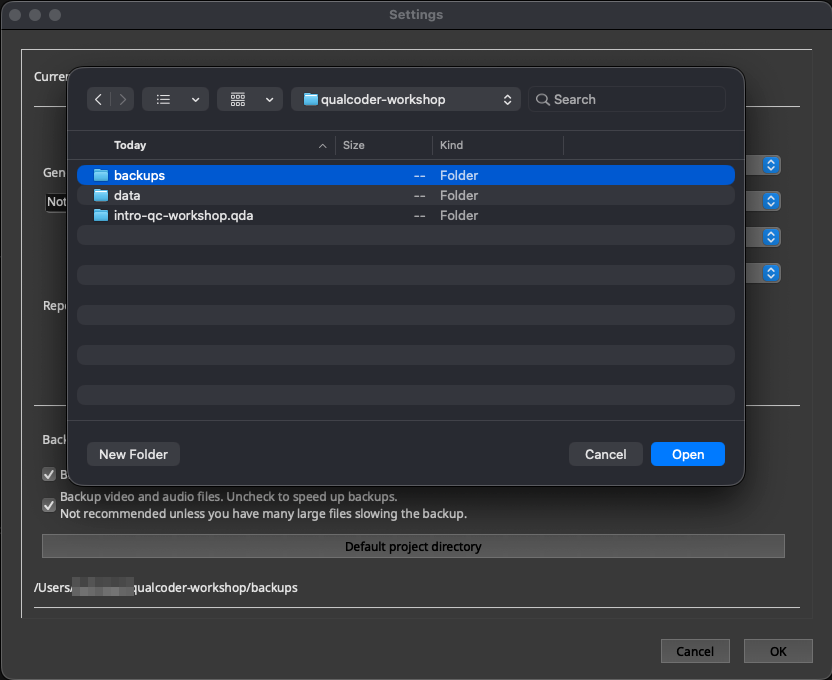

After clicking Default project directory: `backups` selected inside `qualcoder-workshop`, ready to click Open.

**Windows**

**NoteIn QualCoder: set the backup folder**

1. Go to **Project > Settings** (or **Alt + S**).
2. Click **Default project directory**.
3. Go to `qualcoder-workshop` and click **once** on `backups` to select it (don’t double-click into it).
4. Click **Select Folder**.
5. Click **OK**.

[figure not shown]

After clicking Default project directory: the backups folder selected, ready to click Select Folder.

QualCoder makes a backup each time you open the project and keeps up to 5 backups in this folder. When it saves a new one, it deletes the oldest. Backups are folders named like `intro-qc-workshop_BKUP_<date>_<hour>.qda`. Your first one appears the next time you open the project; you’ll see it at the end of the session (Section 7).

## 3.5 Confirm your settings

When you click **OK** to close the settings, QualCoder reports the project settings and any changes in the **Action Log** tab. It updates every time you change the project.

**NoteIn QualCoder: check the Action Log**

1. Click the **Action Log** tab.
2. Check that **Coder** shows your coder name and **Working directory** ends with `qualcoder-workshop/backups`.

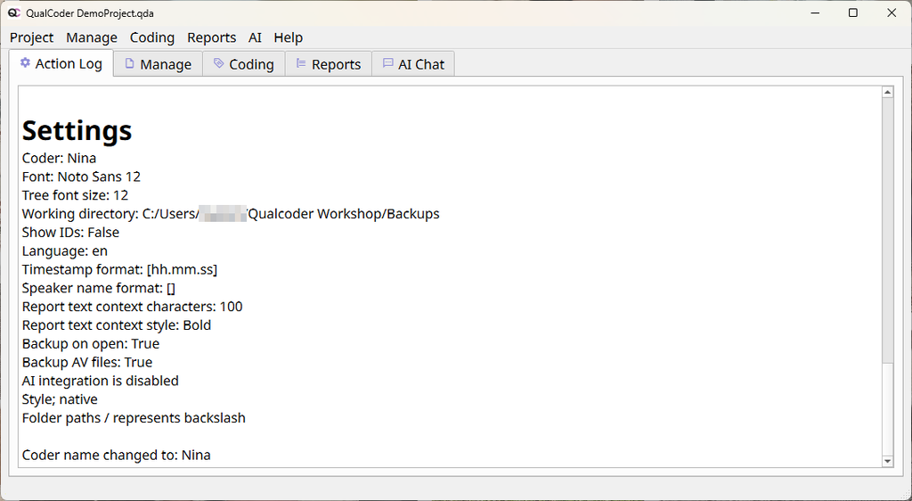

The Action Log after the settings change. The last line confirms the new coder name.

# 4 Import transcripts

## 4.1 Import the files

QualCoder copies each file into the project. Later edits in QualCoder change only that copy; your original in `data/` stays as it was.

**NoteIn QualCoder: import transcripts**

1. In the top menu, click **Manage > Manage Files**. This opens the **Manage** tab.
2. Click the **Import file into project folder** button.
3. QualCoder opens its own **Open file** window. Go to the `data` folder inside `qualcoder-workshop`.
4. Select all three transcripts: click the first, then hold **Shift** and click the last.
5. Click **Open**.

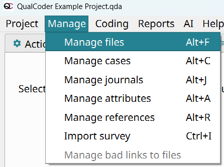

Manage files is the first item in the Manage menu.

[figure not shown]

The Import file into project folder button is the first button on the Manage tab.

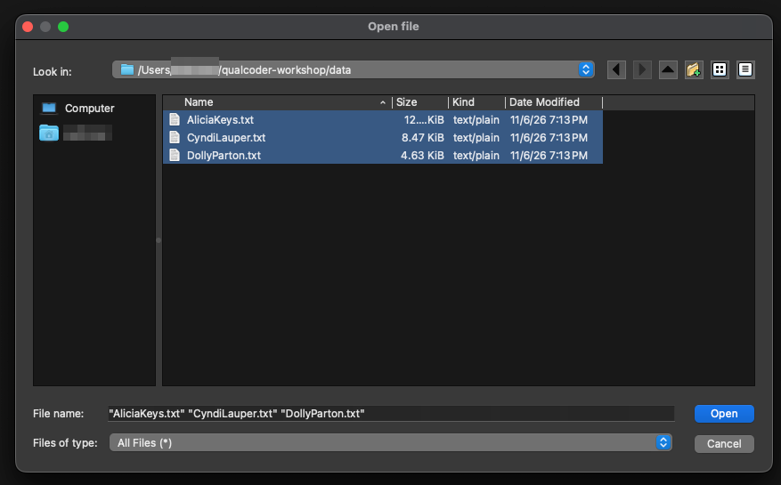

QualCoder’s Open file window in the `data` folder, with all three transcripts selected. It’s QualCoder’s own window, so it looks the same on Mac and Windows.

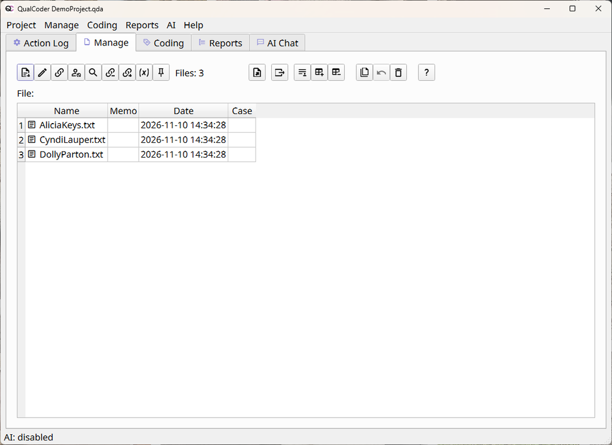

After importing, the Manage tab lists the three transcripts.

## 4.2 Add attributes

Attributes describe your files: for example, the participant’s role, the interview date or the site. They help you keep track of which file is which, and you can use them to filter reports.

We’ll add two attributes to the interviews: the singer’s **Genre** (text) and the **Year** of the recording (a number).

| File | Genre | Year |
| --- | --- | --- |
| DollyParton.txt | Country | 1971 |
| CyndiLauper.txt | Pop | 1983 |
| AliciaKeys.txt | R&B | 2001 |

**NoteIn QualCoder: create two attributes**

1. In the top menu, go to **Manage > Manage Attributes**.
2. Click the **(x)** button to add an attribute.
3. In the **Add Attribute** window, type `Genre`, choose **Character** (text) and click **OK**.
4. In the **Assign attribute** window, choose **Files** (an attribute can also describe cases or journals) and click **OK**.
5. Click **(x)** again. Type `Year`, choose **Numeric** and click **OK**. Choose **Files** and click **OK**.

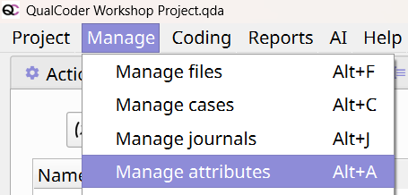

Manage attributes is in the Manage menu.

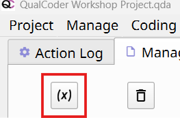

The (x) button adds an attribute.

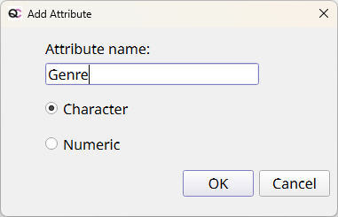

Genre is a Character (text) attribute.

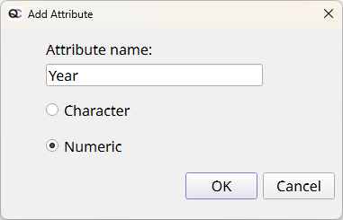

Year is a Numeric attribute.

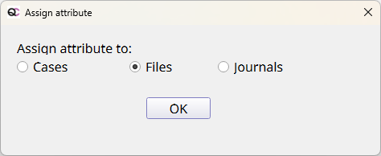

Next, choose Files, so the attribute describes each transcript.

**NoteIn QualCoder: fill in the attribute for each file**

1. Click **Manage > Manage Files**. Each attribute is now a column.
2. Click the cell for each file and type its value from the table above. To edit a value, double-click the cell.

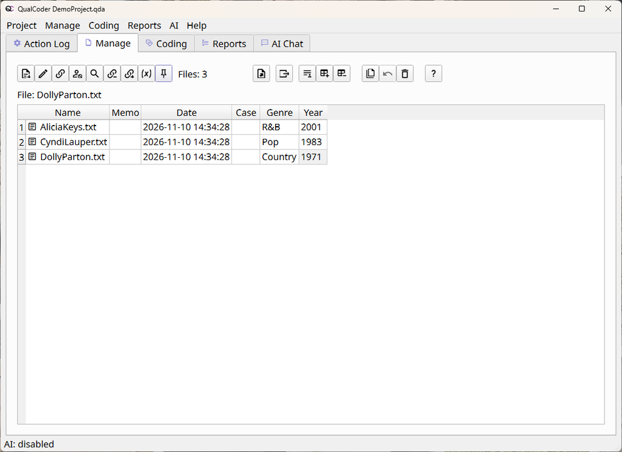

The Manage tab with a Genre and a Year for each transcript.

**TipExtra: put attributes in your own order**

QualCoder lists attributes alphabetically. To set your own order, number them: “1. Year”, “2. Genre”.

# 5 Code your transcripts

## 5.1 Get ready to code

**NoteIn QualCoder: open a transcript for coding**

1. In the top menu, click **Coding > Code Text**. This opens the **Coding** tab.
2. Check that it shows **your name** as the coder. If it doesn’t, click the **…** box next to the coder name and choose your name. (If your name isn’t there, add it in the settings: see Section 3.)
3. Click the name of the transcript you want to code. Its text appears in the large box on the right.

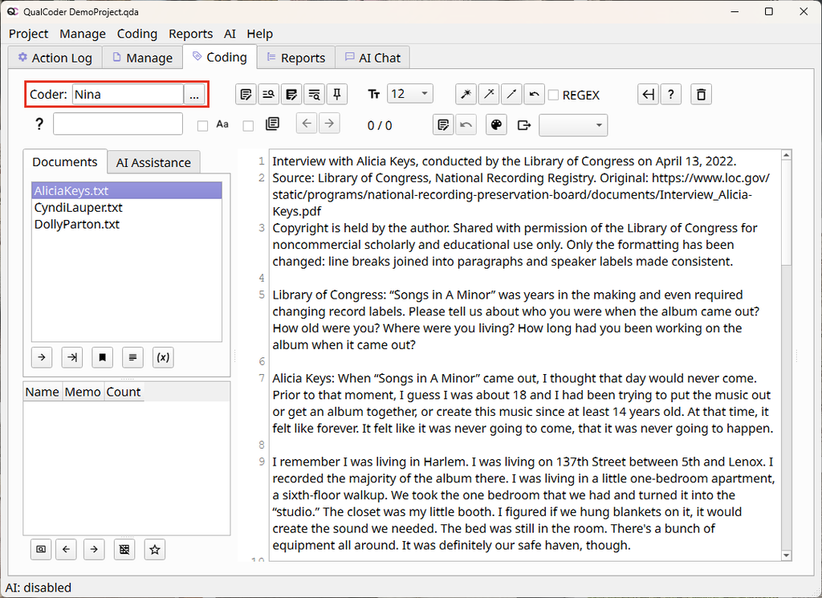

The Coding tab, ready to code: the coder name (boxed), the transcripts on the left and the open transcript on the right.

## 5.2 Demo: coding with example codes

Watch first, then try it. We’ll code part of the Cyndi Lauper interview together, with four example codes that fit our research question. Each code has a short definition, so everyone (and your future self) applies it the same way.

| Code | Use it when the singer… | Where to look, for example |
| --- | --- | --- |
| **Inspiration from life** | ties a song to something that happened to them or people they know | Cyndi Lauper on the loud clock behind “Time After Time” |
| **Industry pushback** | describes the record company, managers or radio disagreeing with them, or them pushing back | Cyndi Lauper on choosing her first single |
| **Faith/spirituality** | mentions God, faith or a spiritual feeling | Alicia Keys on the chorus of “Troubles” |
| **Why it connects** | explains why listeners relate to the song | Dolly Parton on why “Coat” became so dear to people |

A list of codes like this, with definitions and examples, is a **codebook**. In your own research you’d build and revise it as you read.

Highlight the text you want to code, then use a keyboard shortcut or right-click:

| To do this | Shortcut | Or right-click and choose |
| --- | --- | --- |
| Code with a **new** code | **Shift + N** | **Mark with new code (N)** |
| Code with a **recently used** code | **Shift + R** | **Mark with recent code (R)**, then pick from the list |
| **Remove** a code from text | **Shift + U** | **Unmark (U)** |

The shortcuts are the same on Mac and Windows.

**NoteIn QualCoder: code a passage**

1. Open **CyndiLauper.txt**.
2. Highlight her answer about where “Time After Time” came from (the clock and the watch).
3. Press **Shift + N**, type `Inspiration from life` and click **OK**. The passage is highlighted in the code’s color, and the code appears in the codes list on the lower left.
4. Add the other three codes the same way, each on a passage that fits it.
5. Highlight another passage that fits a code you’ve already made, press **Shift + R** and pick the code from the list.
6. To remove a code, click in the coded text and press **Shift + U**.

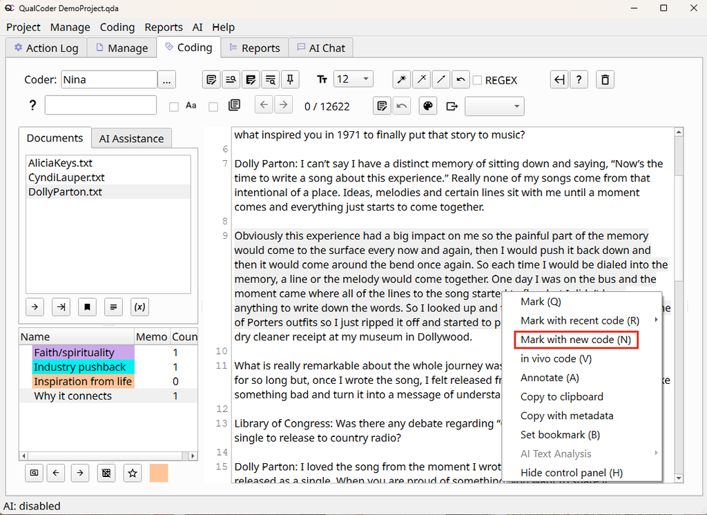

Right-click highlighted text to code it. Mark with new code (N) is boxed.

Right-click in the codes list to rename a code, change its color, add a memo to it, add a new code or category, or delete it.

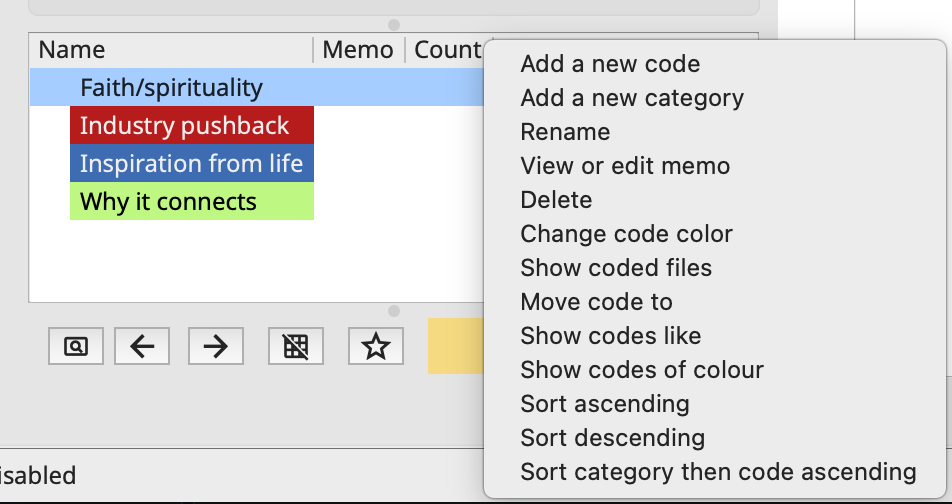

Right-click a code to change it.

## 5.3 Do it yourself: 5 minutes of coding

**NoteIn QualCoder: your turn (5 minutes)**

1. Open **DollyParton.txt**. It’s the shortest of the three.
2. Read it and code passages with the four example codes. If you’d like to, add one code of your own.
3. Try coding one passage with two codes, so it’s underlined.
4. Pick a passage you’ve coded and add a memo to it (see the next section).
5. Finished early? Code some of the Alicia Keys interview, so your reports have more to show.

## 5.4 Memos

A memo is a note attached to coded text. After you code a passage, add a memo that sums it up: what about this text helps answer your research question? For example, on a passage coded *Inspiration from life*: “Turns a painful memory into a song; writing it helped her let go of the hurt.” Later you can run a report of only memos (Section 6), which gives you a head start on writing your analysis.

**NoteIn QualCoder: memo coded text**

1. Code the text first.
2. Click anywhere in the coded text.
3. Press **Shift + M**, or right-click and choose **Memo coded text (M)**.
4. Type your memo and click **OK**. The memo’d text is now *italicized*.

If the text has more than one code, QualCoder asks which code the memo belongs to. That choice decides where the memo shows up in reports.

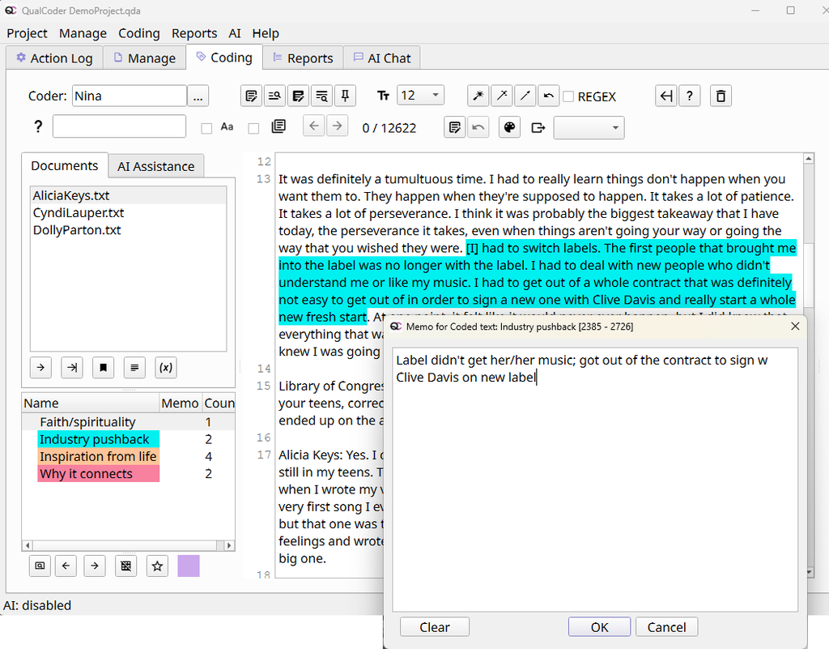

A memo on a passage coded Industry pushback. The window’s title names the code.

## 5.5 Annotations

An annotation explains a piece of text: an acronym, short-hand or a reference a reader wouldn’t know. Unlike a memo, the text doesn’t need to be coded. For example, Dolly Parton mentions “Porter”: an annotation can say that’s Porter Wagoner, the country singer she performed with at the time.

**NoteIn QualCoder: annotate text**

1. Highlight the text that needs explaining.
2. Press **Shift + A**, or right-click and choose **Annotate (A)**.
3. Type the annotation and click **OK**. The annotated text is now **bold**.

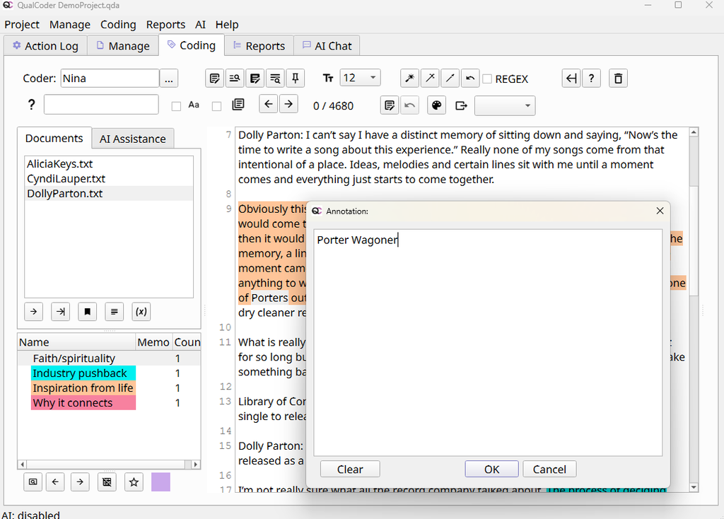

An annotation on “Porter” in the Dolly Parton interview.

## 5.6 What the formatting means

| What you see | What it means |
| --- | --- |
| Highlighted and underlined | The text has 2 or more codes. |
| Highlighted and *italicized* | A memo is attached to the coded text. |
| **Bold** | An annotation is attached to the text. |

In the codes list (lower left of the Coding tab), drag codes to merge them, move them into a category or reorder them. In the color picker, colors marked with an asterisk (*) are already used by a code; hover over one to see which.

# 6 Run reports

A report pulls together all the text for the codes and files you choose. We’ll start with everything: all the codes in all three interviews. Then we’ll add memos to the report.

**Mac**

**NoteIn QualCoder: report all your coded text**

1. In the top menu, click **Reports > Coding reports**.
2. Select all three transcripts: click the first, then hold **Shift** and click the last. (To pick only some, hold **Cmd** and click each one.)
3. Select all the codes, the same way.
4. Leave the memo drop-down at **None**.
5. Click the large **Play** button at the top.

**Windows**

**NoteIn QualCoder: report all your coded text**

1. In the top menu, click **Reports > Coding reports**.
2. Select all three transcripts: click the first, then hold **Shift** and click the last. (To pick only some, hold **Ctrl** and click each one.)
3. Select all the codes, the same way.
4. Leave the memo drop-down at **None**.
5. Click the large **Play** button at the top.

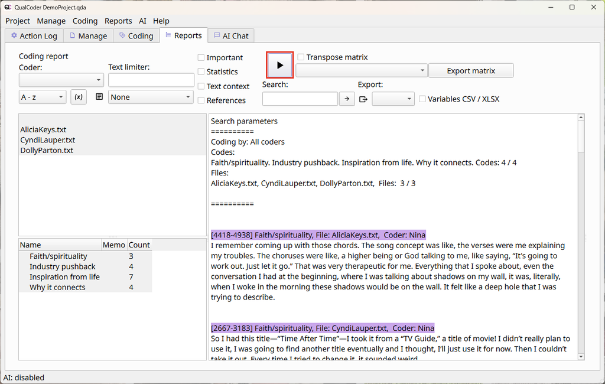

A report of all the codes in all three transcripts. The Play button is boxed. The report window looks the same on Mac and Windows.